# Report on aviation incidents and accidents and their geographic distribution

This report uses open data from the Bundesamt für Flugunfalluntersuchung via mobilithek and the NTSB to look for some interesting corelations and distributions of aircraft accidents and incidents. It should not be intrepreted as a source of safety comparison or as a safety raiting or anything in that direction.

The Questions that intrests us:

- How many, how serious, and where are the aviation incidents and accidents?
- How does this change over the years?
- Does this differ in different countries?

before running this notebook, install the python requirenments and the requrienments for mdbtools. Those can vary with your installation but should be `mdbtools mdbtools-dev unixodbc-dev` then run `make` in the data directory.

Because the german data only contains location names and not coordinates, a database is generated to fill in those coordinates, but sicnce the api used for the name resolution has a max request of 1/s, this is not generated every time. You have to run the `getLatLongForLocations.py` script manually to avoid unneccesary querys.

Since github does not show plotly graphs, either chek this file out or see the .pdf export

### Data loading

```python
import pandas as pd
import matplotlib.pyplot as plt
import plotly.io as pio
import plotly.express as px
import numpy as np

pio.renderers.default = "pdf"


genAvDE = pd.read_sql_table("generalAviation", "sqlite:///../data/de.sqlite")
comAvDE = pd.read_sql_table("commercialAviation", "sqlite:///../data/de.sqlite")
dataDE = pd.read_sql_table("all", "sqlite:///../data/de.sqlite")

us_ac_columns = ["ev_id", "Aircraft_Key", "damage", "acft_make", "acft_model", "acft_series",
		"acft_category", "acft_reg_cls", "elt_manufacturer", "elt_model"]
us_ij_columns = ["ev_id", "Aircraft_Key", "inj_person_category", "injury_level", "inj_person_count"]


eventsUS = pd.read_sql_table("events_clean", "sqlite:///../data/us.sqlite")
aircraftUS =  pd.read_sql_table("aircraft", "sqlite:///../data/us.sqlite")
injuryUS =  pd.read_sql_table("injury", "sqlite:///../data/us.sqlite")


aircraftUS = aircraftUS[us_ac_columns]
injuryUS = injuryUS[us_ij_columns]


partUS = pd.merge(eventsUS, aircraftUS, how="left", on=["ev_id"], validate="1:m")
dataUS = pd.merge(partUS, injuryUS, how="left", on=["ev_id","Aircraft_Key"], validate="1:m")

eventsUS =eventsUS.astype(dtype={"ev_year":int})

locations_de = pd.read_sql_table("locations-new", "sqlite:///../data/loc.de.sqlite")
locations_de.columns = ["Unfallort", "latitude", "longitude"]
dataDE_withLoc = pd.merge(dataDE, locations_de, how="left", on="Unfallort")
```

# Statistics

How much accidents happen and how hard are persons injured every year?

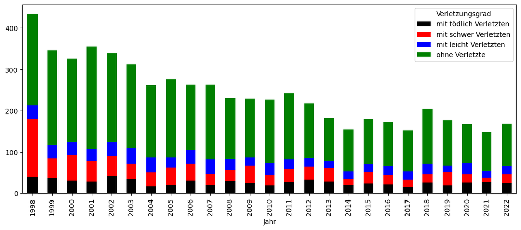

```python
df = dataDE.groupby(["Jahr", "Verletzungsgrad"])["Aktenzeichen"].count()
df = df.reset_index()
df = pd.pivot(df,index="Jahr",columns="Verletzungsgrad")
df.columns =df.columns.get_level_values(1)
df = df.drop(columns="Verletzungen unbekannt")
df.plot.bar(stacked=True, figsize=(13,5), color={'mit leicht Verletzten':"blue", 'mit schwer Verletzten': "red", "mit tödlich Verletzten": "black",'ohne Verletzte': "green"},
            y=["mit tödlich Verletzten", 'mit schwer Verletzten','mit leicht Verletzten', 'ohne Verletzte'])
```

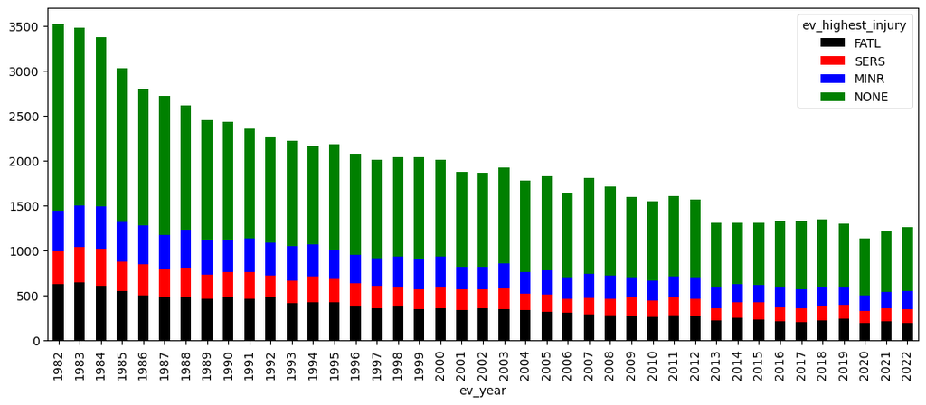

```python
evUS = eventsUS
evUS = evUS[evUS["ev_year"] > 1981]
evUS = evUS[evUS["ev_year"] < 2023]

df = evUS.groupby(["ev_year","ev_highest_injury"])["ev_id"].count()
df = df.reset_index()
df = pd.pivot(df,index="ev_year",columns="ev_highest_injury")
df.columns =df.columns.get_level_values(1)
df.plot.bar(stacked=True, figsize=(13,5),
            y=["FATL","SERS","MINR","NONE"],
            color={"FATL":"black","SERS":"red","MINR":"blue","NONE":"green"}
            )
```

The number of incidents seems to be decreasing over time and most incidents / accidents don't even have someone injured.

This seems to hold for both, but the dip from the flight restrictions during the cov-19 pandemic is more noticable in the US data.

# Graphs

## Where and how serious are the accidents (ACC) and incidents (INC) in the us?

To answer this question, we use plotly to draw a scatterplot of all accidents and incidents in the dataset for which we have coordinates, overlaying it on a map from OpenStreetMap. Then we color the points diferently to gain some insight into where the hotspots may lie, and change the size to visualize how many persons where injured.

```python
df = eventsUS
df = df.replace(r'^\s*$', np.nan, regex=True)
df.dropna(inplace=True)
df = df.astype({"dec_latitude": float, "dec_longitude": float, "inj_tot_t": int})
```

```python
fig1 = px.scatter_mapbox(df,
                        lat="dec_latitude",
                        lon="dec_longitude",
                        color="ev_type",
                        color_discrete_map={"ACC":"red","INC":"blue"},
                        category_orders={"ev_type":["ACC","INC"]},
                        hover_name="ev_id",
                        hover_data=["ev_id", "ev_year", "ev_highest_injury"],
                        center={"lat":35, "lon":-100},
                        zoom=3.5,
                        height=700,
                        width=1200)

fig1.update_layout(mapbox_style="open-street-map")
fig1.update_layout(margin={"r":0,"t":0,"l":0,"b":0})
fig1.show()
```

[output not shown]

```python
fig2 = px.scatter_mapbox(df,
                        lat="dec_latitude",
                        lon="dec_longitude",
                        color="ev_highest_injury",
                        color_discrete_map={"FATL":"black","SERS":"red","MINR":"blue","NONE":"green"},
                        category_orders={"ev_highest_injury":["FATL","SERS","MINR", "NONE"]},
                        hover_name="ev_id",
                        hover_data=["ev_id", "ev_year", "ev_highest_injury"],
                        center={"lat":35, "lon":-100},
                        zoom=3.5,
                        height=700,
                        width=1200)

fig2.update_layout(mapbox_style="open-street-map")
fig2.update_layout(margin={"r":0,"t":0,"l":0,"b":0})
fig2.show()
```

[output not shown]

```python
fig = px.scatter_mapbox(df,
                        lat="dec_latitude",
                        lon="dec_longitude",
                        color="ev_highest_injury",
                        color_discrete_map={"FATL":"black","SERS":"red","MINR":"blue","NONE":"green"},
                        category_orders={"ev_highest_injury":["FATL","SERS","MINR", "NONE"]},
                        size="inj_tot_t",
                        hover_name="ev_id",
                        hover_data=["ev_id", "ev_year", "ev_highest_injury"],
                        center={"lat":35, "lon":-100},
                        zoom=3.5,
                        height=700,
                        width=1200)

fig.update_layout(mapbox_style="open-street-map")
fig.update_layout(margin={"r":0,"t":0,"l":0,"b":0})
fig.show()
```

[output not shown]

## Where and how serious are the accidents (Unfall) and incidents (Schwere Störung) in Germany?

To answer this question, we try to match the location names form the database to coordinates by using geopy / Nominatim. Then we use plotly to draw a scatterplot of all accidents and incidents in the dataset for which we have coordinates, overlaying it on a map from OpenStreetMap. In another chart we color the points diferently to gain some further insight.

```python
dataDE_withLoc = dataDE_withLoc.drop(columns=["Luftfahrzeugart", "Betriebsart"])
dataDE_withLoc = dataDE_withLoc.dropna()

df =dataDE_withLoc
```

```python
figd1 = px.scatter_mapbox(df,
                        lat="latitude",
                        lon="longitude",
                        color="Ereignisschwere",
                        color_discrete_map={"Schwere Störung":"blue","Unfall":"red"},
                        hover_name="Ereignisschwere",
                        hover_data=["Jahr", "Ereignisschwere", "Verletzungsgrad"],
                        center={"lat":52, "lon":10},
                        zoom=5,
                        height=700,
                        width=800)

figd1.update_layout(mapbox_style="open-street-map")
figd1.update_layout(margin={"r":0,"t":0,"l":0,"b":0})
figd1.show()
```

[output not shown]

```python
figd1 = px.scatter_mapbox(df,
                        lat="latitude",
                        lon="longitude",
                        color="Verletzungsgrad",
                        color_discrete_map={"mit tödlich Verletzten":"black","mit schwer Verletzten": "red",
                                            "mit leicht Verletzten": "blue", "ohne Verletzte":"green"},
                        hover_name="Ereignisschwere",
                        hover_data=["Jahr", "Ereignisschwere", "Verletzungsgrad", "Unfallort"],
                        center={"lat":52, "lon":10},
                        zoom=5,
                        height=700,
                        width=800)

figd1.update_layout(mapbox_style="open-street-map")
figd1.update_layout(margin={"r":0,"t":0,"l":0,"b":0})
figd1.show()
```

[output not shown]